# ME116 - Introduction to Statistics: Understanding the World through Data

Class 1 - Data Summaries

Xinhui Liu

23 June, 2025

## **Question 1**

The file $\texttt{midterm.csv}$ contains a sample of 100 midterm exam scores from students who took this course in the period 2011-17.

```r
midt <- read.csv("D:/R data/midterm.csv") # replace this with your own path
midt[1:10,]  # select the first ten observations
```

```
##  [1] 77 44 72 29 71 36 70 63 67 77
```

```r
colnames(midt)
```

```
## [1] "x"
```

```r
score <- midt$x  # define a variable score which is the x column of midt
score
```

```
##   [1] 77 44 72 29 71 36 70 63 67 77 72 50 55 59 90 25  9 72 49 64 22 75 56 45 81
##  [26] 75 65 32 48 53 83 53 76 74 44 65 88 59 76 88 42 44 99 58 52 50 86 46 41 24
##  [51] 89 43 85 63 67 56 82 73 41 90 66 62 76 47 65 56 71 90 62 50 69 62 40 62 67
##  [76] 56 60 65 68 65 75 70 89 60 18 62 61 76 91 27 56 64 94 57 42 42 57 70 62 66
```

### **(a)**

Compute the mean and median exam scores.

```r
mean(score)  # mean score
```

```
## [1] 61.38
```

```r
sum(score) / length(score)  # alternative way
```

```
## [1] 61.38
```

```r
median(score)  # median score
```

```
## [1] 62.5
```

### **(b)**

Compute the quartiles and interquartile range, then draw a box plot of the data.

```r
summary(score)  # summary of the data
```

```
##    Min. 1st Qu.  Median    Mean 3rd Qu.    Max.
##    9.00   50.00   62.50   61.38   73.25   99.00
```

```r
quantile(score, 0.25)  # 1st quartile
```

```
## 25%
##  50
```

```r
quantile(score, 0.75)  # 3rd quartile
```

```
##   75%
## 73.25
```

```r
quantile(score, 0.5)  # median
```

```
##  50%
## 62.5
```

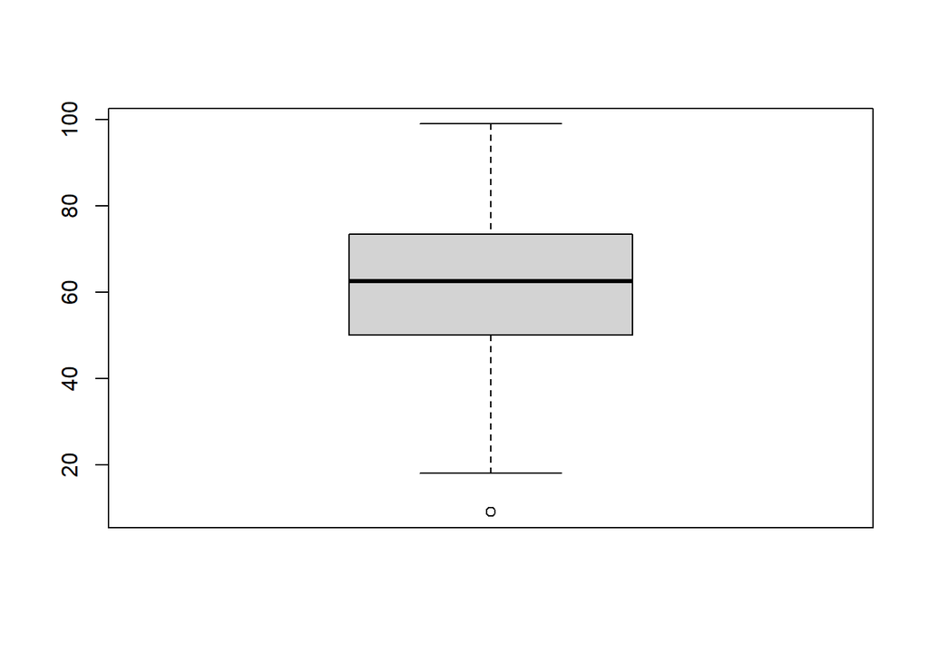

```r
IQR <- quantile(score, 0.75)  - quantile(score, 0.25)  # IQR of the data
boxplot(score)  # box plot
```

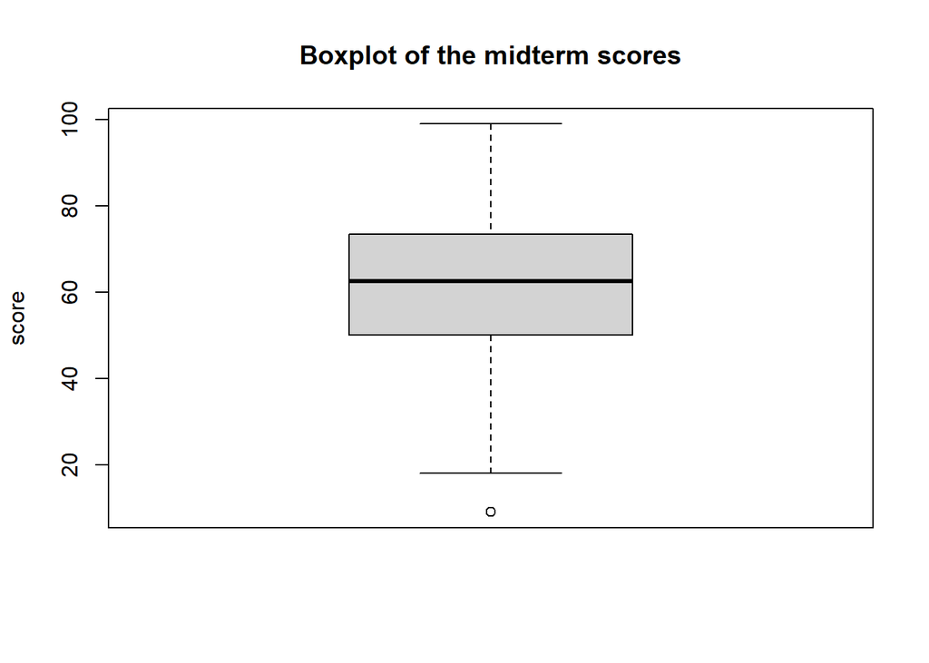

```r
boxplot(score, main = "Boxplot of the midterm scores", ylab = "score")
```

### **(c)**

Compute the standard deviation of the scores. What proportion os students scored within 2 standard deviations of the mean?

```r
sd(score)  # standard deviation of the data
```

```
## [1] 18.16578
```

```r
sqrt( sum( (score - mean(score)) ^2) / (length(score) - 1) )  # alternative way
```

```
## [1] 18.16578
```

```r
m_2sdl <- mean(score) - 2 * sd(score)  # mean - 2*sd
m_2sdh <- mean(score) + 2 * sd(score)  # mean + 2*sd
m_2sdl
```

```
## [1] 25.04844
```

```r
m_2sdh
```

```
## [1] 97.71156
```

```r
score > m_2sdh  # check whether each score is above mean + 2*sd
```

```
##   [1] FALSE FALSE FALSE FALSE FALSE FALSE FALSE FALSE FALSE FALSE FALSE FALSE
##  [13] FALSE FALSE FALSE FALSE FALSE FALSE FALSE FALSE FALSE FALSE FALSE FALSE
##  [25] FALSE FALSE FALSE FALSE FALSE FALSE FALSE FALSE FALSE FALSE FALSE FALSE
##  [37] FALSE FALSE FALSE FALSE FALSE FALSE  TRUE FALSE FALSE FALSE FALSE FALSE
##  [49] FALSE FALSE FALSE FALSE FALSE FALSE FALSE FALSE FALSE FALSE FALSE FALSE
##  [61] FALSE FALSE FALSE FALSE FALSE FALSE FALSE FALSE FALSE FALSE FALSE FALSE
##  [73] FALSE FALSE FALSE FALSE FALSE FALSE FALSE FALSE FALSE FALSE FALSE FALSE
##  [85] FALSE FALSE FALSE FALSE FALSE FALSE FALSE FALSE FALSE FALSE FALSE FALSE
##  [97] FALSE FALSE FALSE FALSE
```

```r
sum(score > m_2sdh)  # count how many scores are above mean + 2*sd
```

```
## [1] 1
```

```r
score < m_2sdl  # check whether each score is below mean - 2*sd
```

```
##   [1] FALSE FALSE FALSE FALSE FALSE FALSE FALSE FALSE FALSE FALSE FALSE FALSE
##  [13] FALSE FALSE FALSE  TRUE  TRUE FALSE FALSE FALSE  TRUE FALSE FALSE FALSE
##  [25] FALSE FALSE FALSE FALSE FALSE FALSE FALSE FALSE FALSE FALSE FALSE FALSE
##  [37] FALSE FALSE FALSE FALSE FALSE FALSE FALSE FALSE FALSE FALSE FALSE FALSE
##  [49] FALSE  TRUE FALSE FALSE FALSE FALSE FALSE FALSE FALSE FALSE FALSE FALSE
##  [61] FALSE FALSE FALSE FALSE FALSE FALSE FALSE FALSE FALSE FALSE FALSE FALSE
##  [73] FALSE FALSE FALSE FALSE FALSE FALSE FALSE FALSE FALSE FALSE FALSE FALSE
##  [85]  TRUE FALSE FALSE FALSE FALSE FALSE FALSE FALSE FALSE FALSE FALSE FALSE
##  [97] FALSE FALSE FALSE FALSE
```

```r
sum(score < m_2sdl)  # count how many scores are below mean - 2*sd
```

```
## [1] 5
```

```r
length(score) - sum(score > m_2sdh) - sum(score < m_2sdl)  # how many scores are between mean - 2*sd and mean + 2*sd
```

```
## [1] 94
```

### **(d)**

Draw a histogram of exam scores and comment on its shape.

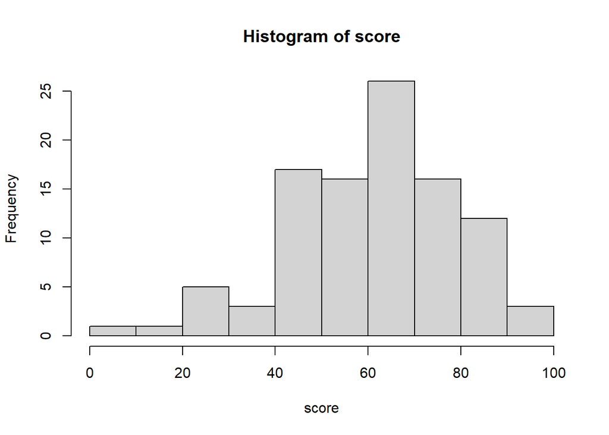

```r
hist(score)  # histogram
```

Some evidence of $\textbf{left skew}$, due to the upper bound at 100.

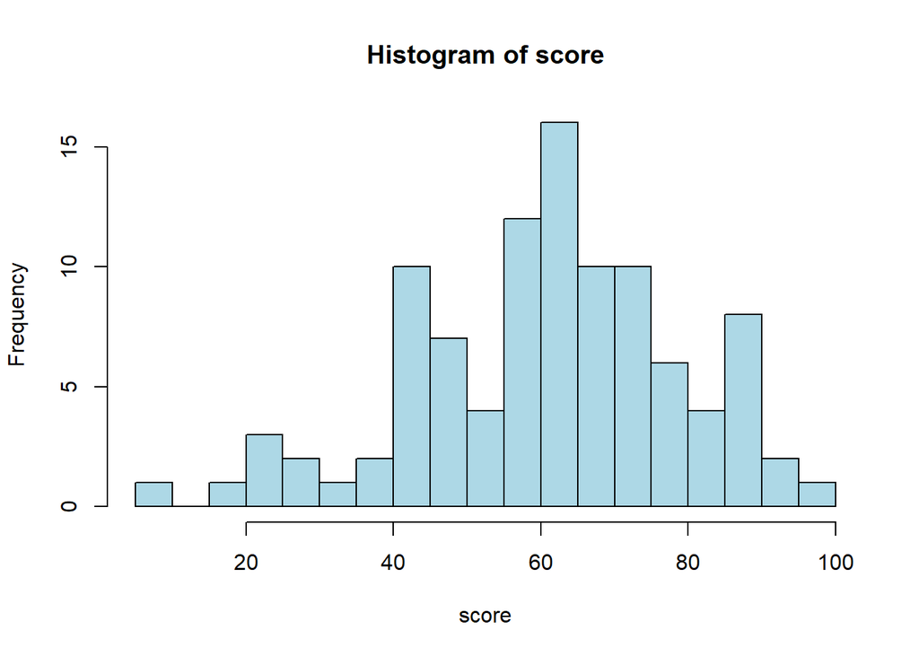

```r
hist(score, breaks = 15, col = 'light blue')
```

### **(e)**

Using the histogram you have drawn, estimate the probability that a randomly chosen student:

- passes the course;
- obtains a grade of A- or higher

```r
letter <- read.csv("D:/R data/letter_grades.csv") # replace this with your own path
letter
```

```
##   grade  range
## 1     F   0-39
## 2     C  40-41
## 3    C+  42-47
## 4    B-  48-49
## 5     B  50-59
## 6    B+  60-64
## 7    A-  65-69
## 8     A  70-79
## 9    A+ 80-100
```

```r
sum(score >= 40) / length(score)
```

```
## [1] 0.91
```

```r
sum(score >= 65) / length(score)
```

```
## [1] 0.46
```

## **Question 2**

Find a recent example in a newspaper/magazine/blog of a plot that is confusing or misleading. Suggests ways to improve it (or draw an improved plot!)

In $\textit{Financial Times}$, this chart was described as “[One of the worst charts ever](https://www.ft.com/content/58dce921-2cdf-4140-9eb7-77792749dc88).” In an article by ABC encouraging the rental of vacant homes to ease the housing crisis, a line chart was used:

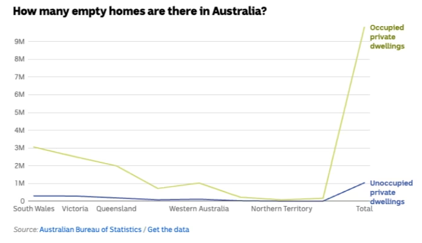

But there were several design problems:

- The label of x axis was unclear: The “total” (overall number) was placed on the same axis as regional indicators, making the comparison meaningless;
- A line chart was used instead of a more appropriate bar chart for categorical comparison.